# CS_04

Zhongyu Zhou

2024-09-25

## Introduction

In this report, we will explore flight data from the “nycflights13” package. Specifically, our goals are to: 1. Identify the destination airports farthest from New York City airports. 2. Map the airport locations 3. Calculate the average delay for each destination and map it.

We will use a variety of data wrangling techniques to achieve these goals.

## Step 1: Load necessary packages

We begin by loading the required libraries. The `tidyverse` package is essential for data manipulation, `nycflights13` contains the flight and airport data, and `maps` is used for plotting geographic maps.

```r
library(tidyverse)
```

```r
library(nycflights13)
library(maps)
```

## Step 2: View the datasets

Let’s start by skimming through the first few rows of the flights and airports datasets to get a feel for their structure. This helps us identify relevant columns, such as destination code and coordinates, for subsequent analysis.

```r
# View the first few rows of the flights dataset
head(flights)
```

```
## # A tibble: 6 × 19
##    year month   day dep_time sched_dep_time dep_delay arr_time sched_arr_time
##   <int> <int> <int>    <int>          <int>     <dbl>    <int>          <int>
## 1  2013     1     1      517            515         2      830            819
## 2  2013     1     1      533            529         4      850            830
## 3  2013     1     1      542            540         2      923            850
## 4  2013     1     1      544            545        -1     1004           1022
## 5  2013     1     1      554            600        -6      812            837
## 6  2013     1     1      554            558        -4      740            728
## # ℹ 11 more variables: arr_delay <dbl>, carrier <chr>, flight <int>,
## #   tailnum <chr>, origin <chr>, dest <chr>, air_time <dbl>, distance <dbl>,
## #   hour <dbl>, minute <dbl>, time_hour <dttm>
```

```r
# View the first few rows of the airports dataset
head(airports)
```

```
## # A tibble: 6 × 8
##   faa   name                             lat   lon   alt    tz dst   tzone
##   <chr> <chr>                          <dbl> <dbl> <dbl> <dbl> <chr> <chr>
## 1 04G   Lansdowne Airport               41.1 -80.6  1044    -5 A     America/Ne…
## 2 06A   Moton Field Municipal Airport   32.5 -85.7   264    -6 A     America/Ch…
## 3 06C   Schaumburg Regional             42.0 -88.1   801    -6 A     America/Ch…
## 4 06N   Randall Airport                 41.4 -74.4   523    -5 A     America/Ne…
## 5 09J   Jekyll Island Airport           31.1 -81.4    11    -5 A     America/Ne…
## 6 0A9   Elizabethton Municipal Airport  36.4 -82.2  1593    -5 A     America/Ne…
```

## Step 3: Find the farthest airport

Next, we want to identify the farthest destination airport from any of the NYC airports. We will sort the flights dataset by distance and select the flight with the greatest distance. After finding the corresponding airport code, we will look up the full name of the airport.

```r
# Find the farthest flight by sorting by distance
farthest_flight <- flights %>%
  arrange(desc(distance)) %>%
  slice(1)  # Get the top row with the maximum distance

# Extract the destination airport code
farthest_code <- farthest_flight %>%
  pull(dest)

# Print the airport code
farthest_code
```

```
## [1] "HNL"
```

```r
# Join with the airports dataset to get the full airport name
farthest_airport <- farthest_flight %>%
  left_join(airports, by = c("dest" = "faa")) %>%
  select(name) %>%
  as.character()

# Print the name of the farthest airport
farthest_airport
```

```
## [1] "Honolulu Intl"
```

## Step 4: Plot airport locations on a world map

Now, let’s visualize all the airports using their geographic coordinates (longitude and latitude). We’ll plot these points on a world map with red dots marking each airport.

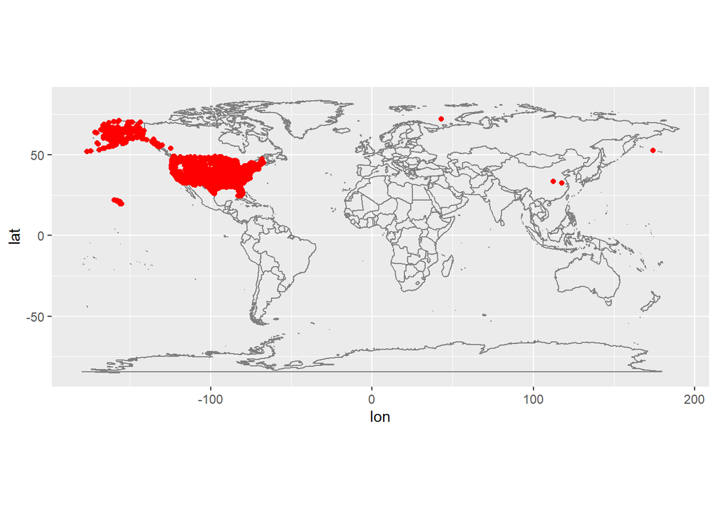

```r
# Plot airport locations on a world map
airports %>%
  distinct(lon, lat) %>%
  ggplot(aes(lon, lat)) +
  borders("world") +  # Draw the world map
  geom_point(col="red") +  # Red dots represent airports
  coord_quickmap()  # Keep the correct map proportions
```

## Step 5: Plot average delay by destination airport

Here, we calculate the average arrival delay for each destination airport. We group the flight data by the destination airport code (dest) and then use mean() to calculate the average delay, excluding missing values (NA). We then plot a map to visualize the average delays across the United States. Red indicates long delays, blue indicates early arrivals, and white indicates no delays.

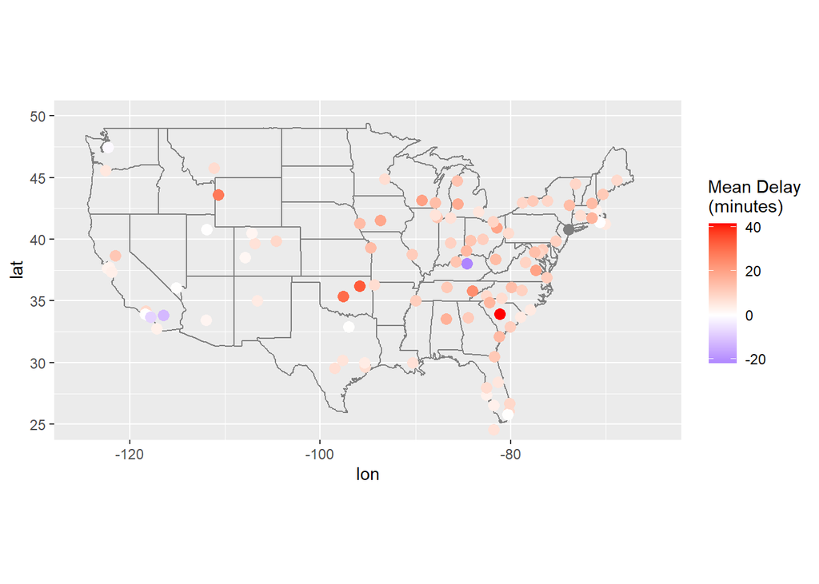

```r
# Calculate average delay by destination airport
mean_delay <- flights %>%
  group_by(dest) %>%
  summarise(mean_delay = mean(arr_delay, na.rm = TRUE)) %>%
  left_join(airports, by = c("dest" = "faa"))  # Join with airports to get latitude and longitude

# Plot the map of the United States with mean delays
ggplot(mean_delay, aes(lon, lat)) +
  borders("state") +  # Add state boundaries
  geom_point(aes(color = mean_delay), size = 3) +  # Color points based on delay
  scale_color_gradient2(low = "blue", mid = "white", high = "red", midpoint = 0, name = "Mean Delay\n(minutes)") +  # Color gradient
  coord_fixed(ratio = 1.3, xlim = c(-125, -65), ylim = c(25, 50))  # Fix the aspect ratio and set map limits
```

## Conlusion

For this case study, we identified the destination airports farthest from New York City, calculated the average delay at each destination airport, and visualized these delays on a map of the United States.